# GIS Einführung mit QGIS

## 5.4 SpatiaLite und SpatiaLite-GUI

Wie eingangs erläutert, beruht SpatiaLite ebenfalls auf SQLite, es kann keine Rasterdaten speichern, hat eine deutlich längere Entwicklung hinter sich und bietet eine eigene GUI (graphical user interface). SpatiaLite-Datenbanken können wie GPKG durch den Export von Layern in QGIS erzeugt, gefüllt und nach der Verbindung mit QGIS-Bordmitteln genutzt werden. Bis zu diesem Punkt ergibt sich kein Mehrwert bei der Nutzung. SpatiaLite erlaubt es von anbeginn, *spatial views* zu erstellen. Das ist in QGIS nun mit “[x] Als neuen Layer laden” ebenfalls möglich. Daneben bitet SpatiaLite, nachfolghend mit der zugehörigen GUI genutzt einige Vorteile.

| Anmerkung |
| --- |
| Die Unterschiede zwischen der QGIS DB-Verwaltung und der SpatiaLite GUI bei der Erstellung und Darstellung der jeweiligen Dateien werden am Ende kurz erläutert. |

### 5.4.1 SpatiaLite installieren

Laden Sie sich bitte von der [Website](http://www.gaia-gis.it/gaia-sins/) die Dateien für SpatiaLite herunter. Unten links sehen Sie die “MS Windows binaries”.

1. Wählen Sie hier bei “**latest version supporting spatialite GUI**”, je nach System 32bit oder 64bit. Nur bei dieser Version ist die GUI dabei. Offensichtlich hat die Entwicklung dieser GUI keine Priorität.
2. Sie sehen drei gepackte Dateien (.7z), die Sie herunterladen.
3. Legen Sie im Ordner “Program Files” (64bit) oder “Program Files (x86)” einen neuen Ordner “spatialite” an und kopieren Sie alles dort hinein (Adminrechte). Da die Datei proj.db in jeder der gepackten Dateien vorliegt, belasse ich … modules… und …tools… in ihrem jeweiligen Unterordner. Das Programm wird nicht installiert, d.h. im Betriebssystem eingebunden, der Ordner “SpatiaLite” kann also überall liegen.
4. Wenn Sie es zukünftig öfter nutzen wollen und mehr Komfort wünschen, können Sie die Datei “spatialite_gui.exe” mit dem Eintrag “An Start anheften” über das Kontextmenü in das Startmenü der Programme eintragen. Oder erstellen Sie einen Link in “c:\ProgramData\Microsoft\Windows\Start Menu\Programs\”

Zu SpatiaLite gibt es zahlreiche ergänzende Infos:

- SpatiaLite: http://www.gaia-gis.it/gaia-sins/
- SpatiaLite Funktionsliste: https://www.gaia-gis.it/gaia-sins/spatialite-sql-5.1.0.html
- SpatiaLite Doku: https://www.gaia-gis.it/fossil/libspatialite/wiki?name=misc-docs (sehr alt)

### 5.4.2 SpatiaLite GUI

Starten Sie die SpatiaLite-GUI und erstellen Sie mit “Menue > MEMROY DB > Creating a New …”. Diese Datenbank wird unmittelbar geöffnet und verändert die GUI (s. u.). In der Iconleiste sind einige Symbole ausgegraut, wenn Sie nicht alle Teilanwendungen (Dateien) heruntergeladen haben.

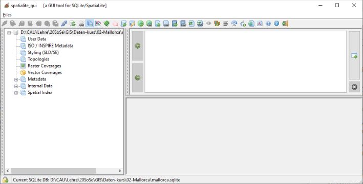

SpatiaLite-GUI.

Importieren Sie einmalig eine shp-Dateien, z.B. (autonomias): “Menu -> Advanced -> Load Shapfile”. Nach der Auswahl der shp-Datei erscheint ein Fenster, in dem Sie jeweils angepasst folgende Parameter setzen: Table name: autonomias, GeomColumn name: geom, SRID: Vorgabe sollte stimmen, Charset Encoding: UTF-8 (wird leider nicht automatisch ausgelesen, steht am Ende des Liste für Charset Encoding, die Info finden Sie in der Datei *.cpg), der Rest bleibt nach Vorgabe.

Der Import von Text-Tabellen ist leider nicht so komfortabel wie in QGIS, z.B. können Geometrien beim Import nicht direkt erstellt werden und zu überspringende Zeilen am Dateianfang gibt es ebenfalls nicht.

Dazu bietet die GUI einen sehr effizienten Import für einzelne DXF-Dateien oder den desamten Inhalt eines Ordners (z.B. CAD-Pläne von Ausgrabungen). Dies erfolgt deutlich effizienter und meist erfolgreicher als bei QGIS. Die übernommen Daten werde *a priori* nach der Geometrie getrenn, z.B. line_layer_2d, polyg_layer_3d, und die Herkunft wird in entsprechenden Spalten für den Datei- und Layernamen hinterlegt. Während die CAD-Datei noch einen wust an Layern besessen haben, ist es hier deutlich übersichtlicher (s. [Tutorial Brics-CAD](https://zenodo.org/records/10614695)).

### 5.4.3 Unterschiede QGIS & Spatialite GUI

Der wesentliche Unterschied für uns als Nutzer, ist die jeweils gebotene Funktionalität. Je nach Bedarf können Sie also wählen, ob Sie lieber mit dem einen oder anderen System arbeiten. Die unmittelbare Darstellung von Abfragen in der Karte (s. “Als neuen Layer Laden”) bei QGIS ist wirklich praktisch. Die GUI von SpatiaLite bietet für mich mit dem DXF-Import einen wichtigen Vorteil.

Verfügbare **Funktionen** wie *st_collect* können bei der SpatiaLite GUI in der Iconleiste ganz rechts, das linke von den beiden (?) als neues Fenster angezeigt werden. Die Performanz und Funktionalität ist hier aber eingeschränkt, weshalb ich immer auf die Version im Netz zugreife: https://www.gaia-gis.it/gaia-sins/spatialite-sql-5.1.0.html. In der DB-Verwaltung finden Sie im SQL-Abfrageeditor ([SQL]-Icon) *dropdown* für diverse Bereiche, so auch die Funktionen. Allerdings fehlt hier z.B. *st_collect* und es wird auch keine Erläuterung zu den Parametern und der Rückgabe geboten.

Ein großer unterschied besteht bei den automatisch generierten und jeweils angezeigten Tabellen und Sichten. Neben der Tabelle KNN2 und unseren “persönlichen” Tabellen tauchen noch diverse Tabellen mit einem “idx_…” am Anfang des Namens auf. Diese dienen der Verwaltung der Geometrien. Dafür wird hier die Tabelle *data_licenses* ausgeblendet, ist aber vorhanden: `select * from data_licenses;`

# 6 Raum & Distanz

## 6.1 Einleitung

Analysen zu archäologischen Fundplätzen und ihrem Umfeld hat es auch vor der *Computer-Revolution* in der Archäologie in den 1980ern und den modernen GIS, ab den 1990ern, gegeben. Ein schönes Beispiel für klassische Techniken der Umfeldanalyse ist die Arbeit von Linke (1976). Die Ursprünge in unserem Fach liegen in der **Siedlungsarchäologie**, in der Fundstellen, das Umfeld und Informationen zur Vegetation oder dem Klima verknüpft und möglichst quantitativ in ihrer Bedingtheit analysiert werden. Hier gibt es eine umfangreiche Literatur, von der ich nur eines nennen will (Jankuhn, 1977). Die uns heute geläufigen theoretischen Grundlagen (zum Beispiel zur Zentralität), die Methoden und auch die Technik kommen aber aus der Geographie, insbesondere der Kultur- und Sozialgeographie (Christaller, 1933; Haggett, 1973). Mit Blick auf Raum und Distanz möchte ich aus der “Findungsphase” im Fach mit Bezug auf das Thema “Raum um die Fundplätze” auf Arbeiten von Zimmermann verweisen (Zimmermann u. a., 2004; Zimmermann und Wendt, 2003) und für Analysen auf der Basis der Distanz auf etwas ältere Arbeiten (Siegmund, 1992; Zimmermann, 1992). Die Verfügbarkeit von Hard- und Software hat zu einem großen Spektrum diverser Interpolationsverfahren geführt, die Punktinformationen in die Fläche übertragen. Eine gute Zusammenfassungen zu diesem Themenkomplex finden Sie bei Herzog (2007). Daneben gibt es zahlreiche spezielle Entwicklungen und Phasen spezifischer Fragestellungen im Fach (z.B. **Aktivitätsareale** , **Archäoprognose**, **Least cost**), auf die ich hier nur hinweisen möchte (Cziesla, 1990; Herzog, 2013; Kunow u. a., 2007). Nach einer Etablierung der Technik im Fach ist meiner Ansicht nach aktuell wieder eine Beschleunigung zu erkennen, die durch bessere technischen Möglichkeiten, neue Methoden der Informationsverarbeitung und mit der Programmiersprache R der Archäologie neue Perspektiven eröffnet (Nakoinz und Knitter, 2016a). Dieser extrem verkürzte Abriss zu GIS in der Archäologie blendet zahlreiche Fragestellungen und vor allem die internationale, oft englischsprachige Literatur aus. Letztere finden Sie aber mit etwas Routine und spezifischen Stichworten in den Repositorien der Fachliteratur.

## 6.2 Umkreisanalyse

### 6.2.1 Vorbemerkungen

Der Gedanke, das Umfeld einer Siedlung als Aktivitäts- und Nutzungsareal für soziale und ökonomische Bedürfnisse zu betrachten, liegt auf der Hand. Damit ergibt sich als erstes die Frage nach dem Radius um die Siedlung. Weitere Fragen ergeben sich aus dem verfügbaren Raum und den möglichen Nachbarn: Wie viel Platz habe ich eigentlich? Welche Siedlung ist gleichzeitig? Diese und weitere, eher archäologische Fragen werden bereits von Linke diskutiert (Linke, 1976, S. 24). Weitere Fragen ergeben sich aus der Geographie, z.B. durch Berge und Flüsse, die unsere Mobilität beeinflussen, diese beschleunigen und begrenzen können. Diese Fragen sind nicht neu und inzwischen oft behandelt worden (u.a. Herzog, 2013). Die jeweilige Antwort beeinflusst als grundlegende Entscheidung das Ergebnis der Analyse. Diese Voraussetzungen (Parameter) sollten anhand der jeweils vorliegenden Daten und der eigenen Fragestellung angemessen als auch nachvollziehbar dargelegt werden.

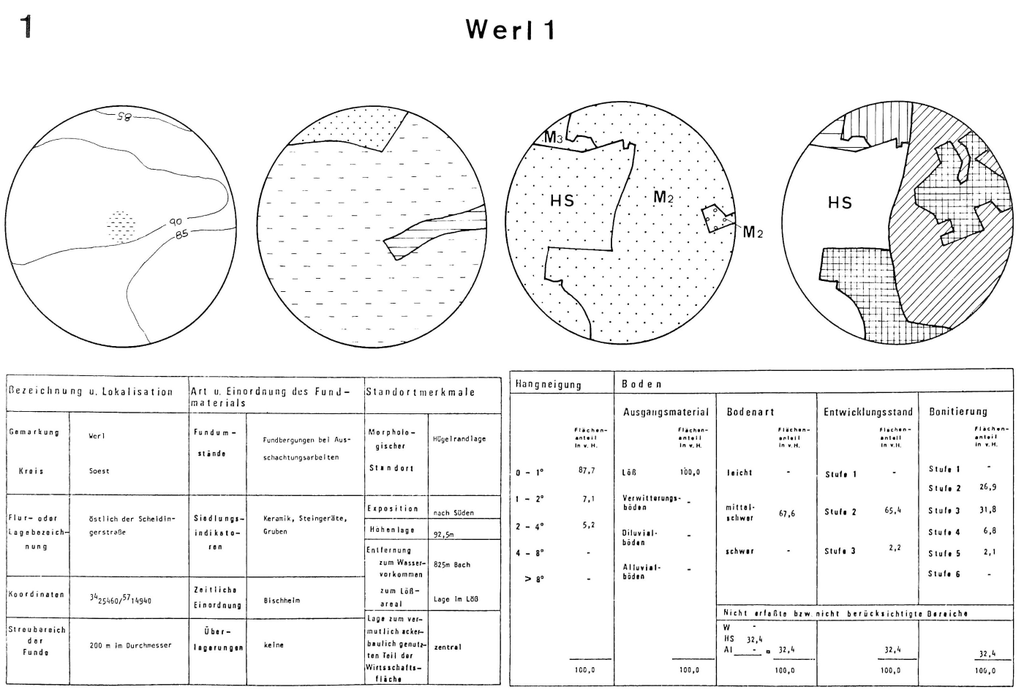

Umkreisanalyse von Linke (1976) mit quantitativer Auswertung.

Um die Technik der Umkreisanalyse von Linke auf unsere Daten anzuwenden, will ich die Frage zur Lage der Talaiots im Geländerelief betrachten: ist diese exponiert, im mittleren Hangbereich oder eher in Tallage? Mein Ansatz ist der Vergleich der Höhenlage des Talaiot zum Umfeld. Dabei sind folgende Angaben zu ermitteln: 1. Die Reliefenergie im Umfeld und 2. die Lage des Talaiot zum Umfeld. Für die Frage der Kreisgröße berücksichtige ich als erstes die Auflösung unseres DGM von 200 m je Rasterzelle und entscheide mich, mangels einfach zu begründender Maße für einen Start mit r = 1 km.

### 6.2.2 Puffer in QGIS

Als Daten verwende ich den originalen Rasterdatensatz des DGM ‘PNOA_MDT200_ETRS89_HU31_Baleares.tif’ aber mit einem auf “DGM 200” verkürztem Layaernamen und einem auf die Talaiots gefilterten Bestand aus der Tabelle *sites* in der SpatiaLite Datenbank: `Tipo_yacim like 'Talaiot%'`. Wie Sie das Umsetzen: 1. im QGIS Layer bei Quelle > [Abfrageerstellung], 2. in der DB-Verwaltung mit einer Abfrage und der Option “Als neuen Layer laden” oder 3. als *spatial view* in der SpatiaLite GUI, ist hier egal. Nachfolgend verwende ich Variante 2 mit dem Layernamen “Talaiots”.

Die Berechnung und Darstellung des Umkreises kann 1. in QGIS erfolgen, wahlweise in eine temporäre Datei oder in eine neue shp-Datei, oder 2. in der DB-Verwaltung von QGIS erfolgen.

#### 6.2.2.1 In der QGIS Toolbox

Im Menü von QGIS wählen Sie “Vektor > Geometrieverarbeitungswerkzeuge > **Puffer**” oder suchen in der *toolbox* nach ‘puffer’ womit Sie auch weitere Varianten finden. Wir nutzen den einfachen ‘Puffer’, setzen Sie hier folgende Parameter: “Eingabelayer”: Talaiots, “Abstand”: 1000 (Meter), belassen Sie den Rest auf den Vorgaben und erstellen einen temporären Layer. Wiederholen Sie den Vorgang, setzen Sie diesmal aber Segmente auf 100. Vergleichen Sie das Ergebnis bei einer großen Auflösung und lesen Sie dazu die Erläuterung rechts im Fenster zum Algorithmus. Starten Sie zum Vergleich auch nochmals die Funktion ‘Vektoren puffern’ aus der GDAL *toolbox*. Beachten Sie die ergänzenden Optionen “Nach Attribut auflösen”, d.h. Überlappende Puffer werden nicht pauschal aufgelöst sondern nur bei identischem Attribut verschmolzen, und “Erzeuge Objekt … Geometriesammlung”, wodurch bei Multi-Objekten, z.B. für jeden Pfosten des Objektes Haus, ein eigener Puffer gezeichnet wird. Die Segmentierung des Kreises wird hier nicht erwähnt, erfolgt aber auch.

| Anmerkung |
| --- |
| Einige Funktionen, z.B. “Variable Pufferbreite” erkennen die Layer aus der Spatialite-DB nicht. Verwenden Sie in diesem Fall die Grass-Funktion und den Parameter “Name der Spalte mit den Pfferdistanze… |
| Trotz identischen Namens bieten und liefern die Tools der diversen Pakete Unterschiede. Und die angewendeten Parameter sind alle wichtig, wenn das Ergebnis nachvollziehbar bleiben soll. |
| Die von Linke (1976) behandelte Frage nach den Standortfaktoren könnte mit dem Werkzeug “Zonenhistogramm” beantwortet werden. Dieses zählt die Häufigkeit der in einem Polygon Vorhandenen, eindeutigen … |
| **Der Layer ist aktuell temporär** und geht beim Schließen verloren. Es sei denn, Sie speichern das Ergebnis als neue, aber im Kern redundante Datei. |

#### 6.2.2.2 Mit SQL in der DB-Verwaltung:

Starten Sie die DB-Verwaltung, öffnen Sie die zugehörige Datenbank, öffnen Sie ein SQL-Fenster und fügen folgenden Befehl ein:

```sql
-- create view talaiots_1km as
SELECT t.ogc_fid, t.nr, t.nombre_yac, t.z_m,
 ST_Buffer(t.geometry, 1000) as geom
from sites as t where t.Tipo_yacim like 'Talaiot%';
```

Die Parameter und die Informationen zum Rückgabewert finden Sie unter: https://www.gaia-gis.it/gaia-sins/spatialite-sql-5.1.0.html

### 6.2.3 Rasterstatistik je Vektor (Kreis)

Im Ergebnis haben wir viele Kreise. Suchen Sie in der *toolbox* nach ‘**Zonenstatistik**’ (zonal stat) und starten Sie diese. Wählen Sie folgende Parameter: “Eingabelayer”: der Puffer, “Rasterlayer”: das Geländemodell (DGM 200 alias mdt 200), “Rasterkanal”: Kanal 1, “Ausgabespaltenpräfix”: s_ (die Vergabe ist frei wählbar, sollte kurz sein und nicht mit einer Zahl starten) und bei “Zu berechnende Statistken”: Wählen Sie bitte alle aus, bis auf ‘Summe’. Im Ergebnis haben Sie bei der Attributtabelle des Verktolayers für jede gewählte Statistik eine neue Spalte. Hier werden dann die englischen Begriffe verwendet. Die **Reliefenergie** ist per Definition die Höhendifferenz in einer Flächeneinheit, Sie ist damit unabhängig von der absoluten Höhe über dem Meer. Zu den ermittelten Werten nachfolgend eine sehr knappe Erläuterung:

- count: Anzahl der betroffenen Zellen
- Sum (abgewählt): Summe der Zellwerte
- mean: der Durchschnitt der gültigen Zellwerte (Zentralwert)
- median: Der Wert in der Mitte der aufsteigend sortierten Zellwerte (Zentralwert)
- stdev: Der Durchschnitt der Differenz jedes Zellwertes zum Mittelwert aller Zellwerte (Streuungsmaß).
- min: der kleinste Wert in einer Zelle
- max: der größte Wert in einer Zelle
- range: Differenz zwischen den beiden vorgenannten Min. und Max. (Streuungsmaß, die Reliefenergie nach Definition)
- minority: am seltensten vorkommende Wert
- majority: am häufigsten auftretende Wert
- variety: Anzahl der unterschiedlichen, eindeutigen Werte
- variance: das Quadrat der Standardabweichung (Durchschnitt der quadrierten Differenzen jedes Wertes zum Mittelwert, Teil der Berechnung der Standardabweichung, Streuungsmaß).

Es gibt hier zahlreiche Werte, die einen Hinweis auf die Reliefenergie geben, vor allem:

- Bereich: Die Differenz zwischen dem kleinsten und größten Wert, wobei ein einzelner Gipfel das Ergebnis deutlich beeinflusst (z.B. der Kilimandscharo). In so einem Fall liegen der Mittelwert und der Median weiter auseinander.
- Standardabweichung: Gibt es viele Hügel und Täler sind viele Werte über ein breites Mittelfeld verteilt, die Standardabweichung ist demnach groß bzw. breit.
- Eindeutige Werte (variety), Vorausgesetzt wir haben Meterangaben oder sogar klassifizierte Werte in Einheiten von 5 Metern ist eine Ebene eher “langweilig”, eine Schräge aber hoch dramatisch. Eine hügeliges Bergvorland, mit vielen Tälern und einem konstanten Anstieg bietet auch viele Unterschiede.

Wollten wir uns einen Überblick über ein Attribut, also eine der zuvor erläuterten Zahlen, von allen Umkreisen verschaffen, können wir aus dem Menü mit “Vektor > Analyse-Werkzeuge > Grundstatistik ..” grundlegende statistische Angaben für das jeweils gewählte Attribut abfragen. Das Ergebnis wird auf Englisch im aktiven Fenster unter dem Reiter “Protokoll” ausgegeben, dazu auf Deutsch in einer hier mit der Pfadangabe zu findenden HTML-Datei. Hier begegnen uns wie zuvor die “üblichen Verdächtigen”, dazu einige weitere Angaben:

**Achtung: en/de unterschiedliche Reihenfolge und einmal falsche Übersetzungen.**

### 6.2.4 Rasterstatistik Tabelle & Protokoll

Das Ergebnis der Rasterstatistik ist erneut ein **temporärer Layer**. Ein schneller Weg zur Sicherung der Ergebnisse ist das Speichern als Tabelle in die SQLite-DB. Über das Kontextmenü “Export > Objekt speichern als …” Format: SpatiaLite, Dateiname: die aktuelle Spatialite-DB, Layername: talaiots1km, Geometrietyp: ohne Geometrie, [] Gespeicherte … hinzufügen (nicht) und [OK]. In der DB-Veraltung die aktuelle DB über das Kontextmenü “Neu verbinden”.

Das ist zwar auch nicht mehr dynamisch, aber Sie können jetzt damit wie mit jeder anderen Tabelle in einer SQL-Datenbank arbeiten. Ein Wehrmutstropfen: Von wann war die Statistik doch noch gleich, vor oder nach der Korrektur der Talaiots? Es sollte also protokolliert werden. Das passiert wahlweise auf einem Papierblatt 👎 oder aber in einer eigenen Tabelle in der DB selbst 👍.

```sql
create table protokoll (name text, createdate text, comment text);
```

```sql
insert into protokoll
select 'talaiots1km', date(), 'Zonenstatistik auf DGM200 zu Talaiots 1km Puffer';
```

### 6.2.5 Visualisierung & Überblick

Kartieren Sie einige der vorgenannten Werte (Bereich, Standardabweichung, Variationskoeffizient und Interquartilabstand). Für die Werte von “Bereich” (range) wähle ich die Farbskala “Spectral” und fünf Klassen mit “Gleiche Anzahl (Quantile)”. Es verwundert nicht, dass die sehr hohen Werte in der Tramuntana zu finden sind und die niedrigen Werte in den zentralen Ebenen von Mallorca.

Der Wechsel auf die Werte der Standardabweichung (stdev) bei Beibehaltung der grafischen Parameter verändert das Bild nur ein wenig, am ehesten noch im mittleren Höhenbereich. Das Problem sind die Klassengrenzen. Betrachten Sie die Histogramme für beide Attribute und verschieben Sie die Grenzwerte nach ihrer Interpretation der “Gipfel” und “Täler” in der Verteilung. Mit Blick auf die vorangehende Erläuterung scheint Folgendes sichtbar: einzelne Gipfel verzerren das Bild. Aus diesem Grund tendiere ich zur Standardabweichung als Indikator einer allgemeine Reliefenergie, die allgemein übliche Maximaldifferenz scheint mir für unsere Frage weniger geeignet.

### 6.2.6 Exponiert oder im Tal?

Ich vergleiche als erstes den Höhenwert der Position des Taliot mit dem Median des Umfeldes (z_m - s_median) und erstelle hierfür mit dem Feldrechner eine neue Spalte (Abakus-Icon). Auch für diesen Wert erstelle ich eine abgestufte Symbologie mit fünf Klassen, kontrolliere direkt das Histogramm und verschiebe die Grenzwerte entsprechend den erkennbaren Abschnitten der Verteilung. Die daraus resultierende Karte zeigt keine räumliche Differenzierung, lediglich die Talaiots im Mittelfeld (+/- 6 m zum Median) liegen sicher aufgrund der fehlenden Reliefenergie in den Ebenen.

[figure not shown]

Histogramm der Differenz von der Lage des Talaiot zum Median des Umfeld (r = 1 km).

Als nächstes möchte ich die Höhenlage des Talaiot mit dem oberen Bereich der umliegenden Höhenwerte vergleichen. Eigentlich würde ich gerne das 3. Quartil (75%) als Schwellwert nehmen, aber der wird mir von der Zonenstatistik leider nicht geboten. Wir sollten also einen Weg finden, ohne das *tool* Zonenstatistik rechnen zu können. Ich helfe mir, indem ich die Standardabweichung zum Mittelwert als dem zugehörigen Zentralwert addiere (mean + stdev) und diese Summe dann vom Höhenwert des Talaiot abziehe (z_m - (mean + stdev)). Auch hier wähle ich zur Darstellung in der Karte eine abgestufte Symbologie mit fünf Klassen, die ich mir im Histogramm direkt ansehe und die Grenzen entsprechend der sichtbaren Verteilung anpasse. Im Ergebnis sehe ich in der Karte ein breit gestreutes Mittelfeld und die “niedrigen”, versteckten Lagen finden sich aufgrund der Topographie natürlich in der Tramuntana. Eher unerwartet ist die recht gleichmäßige Verteilung der exponierten Talaiots, die oberhalb der oberen Standardabweichung liegen. Hier sollten wir zuerst das statistische Ergebnis zur Lage im Gelände individuell prüfen (so viele sind es nicht) und uns dann die weiteren Eigenschaften dieser Talaiots ansehen. Liegen hier besonders monumentale Konstruktionen vor, die eine Deutung als Standorte von zentraler Bedeutung bestärken?

[figure not shown]

Histogramm der Differenz von Siedlungslage zur oberen Standardabweichung des Umfeld (r=1km).

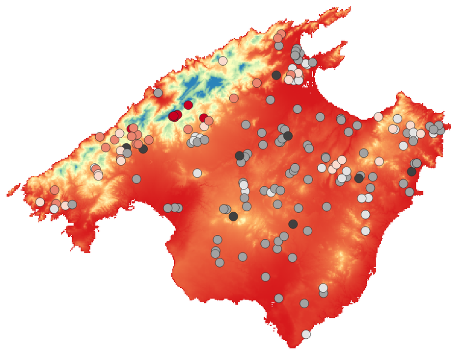

Karte der Differenz von Siedlungslage zur oberen Standardabweichung des Umfeld (r=1km).

**Die Puffer und unsere Berechnungen sind temporäre Layer**, sie werden nicht für uns gespeichert und müssen als weitgehend redundante Daten getrennt gesichert werden.

## 6.3 Thiessen-Polygon, Voronoi-Diagram und Interpolation

Thiessen-Polygone (alternativ Delaunay-Triangulation) sind eine Dreiecksvermaschung, bei der innerhalb des Umkreises zum gebildeten Dreieck kein weiterer Punkt liegt. Die Fundplätze bilden die Knoten (Punkte) der Kanten (Linien). Um die Fundplätze in das Zentrum einer Fläche zu bringen und so die Informationen des Punktes in die umliegende Fläche zu übertragen, wird auf jeder Kante die Mittelsenkrechte gebildet und bis zum Schnittpunkt mit einer anderen Mitttelsenkrechten verlängert. Es entsteht ein dualer Graph, der durch erneutes Bilden der Mittelsenkrechten wieder zum Ausgangsmodell führt.

Bei diesem Verfahren gibt es methodische Probleme, zu denen noch spezifische der Archäologie zu ergänzen sind. Das grundlegende archäologische Problem gleich vorweg: Im Unterschied zu strategisch verteilten (Zufall, Raster etc) und erhobenen Messwerten in der Geographie sind archäologische Nachweiskarten durch viele Faktoren beeinflusst: Aktivität von Ehrenamtlichen, Erhaltung, Vegetation, Landschaftsnutzung etc. Wir müssen also mit dem Fehlen relevanter Informationen rechnen.

Ein methodisches Problem der Triangulation ist der Randeffekt des Netzes. Da hier die jeweiligen Nachbarn fehlen, werden besonders lange Strecken gebildet. Auch ignoriert die geradlinige Verbindung zwischen den Punkten weitere beeinflussende Faktoren der unterstellten räumlichen Nähe: Gebirgszüge, Steilhänge, Flüsse etc. Wird in dem abgeleitete Voronoi-Diagram mit dem Punkt im Zentrum die Information unverändert vom Punkt auf die Fläche übertragen, entstehen an den Grenzen zu den benachbarten Feldern Sprünge in den Information statt fließender Übergänge. Aufgrund dieser Nachteile sind zahlreiche weitere Interpolationsverfahren entwickelt worden. Ein weit verbreitetes ist das *inverse distance weighting* (**IDW**). Die hierbei gewählte Gewichtung muss angemessen sein und kann durch eine Potenz variiert werden. Das in der Geographie ebenfalls gerne genutzte *kriging* bietet noch mehr Justierungsmöglichkeiten, wodurch sich z.B. bei Höhenmodellen sehr gute Approximationen an die Wirklichkeit erzielen lassen. Diese letztgenannten Berechnungen werden nicht nur rechnerisch komplexer, sondern vor allem im Rahmen einer auf archäologischen Argumenten beruhenden Modellbildung schwieriger begründbar. Für die Anwendung in der Archäologie lesen Sie hierzu zum Einstieg bitte (Herzog, 2007). Eine jüngere Darstellung mit komplexen, interdisziplinär ausgearbeiteten und begründeten Modellierungen von Informationen in die Fläche finden Sie u.a. bei Daniel Knitter (Knitter u. a., 2019; Nakoinz und Knitter, 2016b).

## 6.4 Thiessen-Polygone und triangulierte Distanzen

Wie zu Beginn dieses Kapitels erwähnt sind die triangulierte Distanzen ein schlichtes aber durchaus interessantes Maß (Siegmund, 1992; Zimmermann, 1992). Wir können dies bei unserem vorliegenden Datensatz zu den Talaiots einmal durchspielen. Dabei haben wir aus der archäologischen Perspektive bestimmte Vorteile. Durch die klare Begrenzung des Untersuchungsgebietes als Insel sind Kanteneffekte zwar zu erwarten, entsprechen aber der unabdingbaren Realität auch wenn die “Wege” an einige Stellen über das Wasser führen. Der monumentale Charakter und der relativ späte Landesausbau mit dem vorhandenen Bewusstsein für diesen Denkmaltyp hat zu einer erwartbar guten Kenntnis (nicht zwingend Erhaltung) geführt. Wir können zudem mehrstufig Arbeiten und die gesamte Insel mit den Landschaftsgebieten (*comarcas*) oder der zuvor herausgestellten Lage vergleichen.

### 6.4.1 Vorgehen in QGIS

Der Weg ist mehrstufig. Wenn Sie ausschließlich in QGIS arbeiten wollen, müssen Sie folgende Schritte durchlaufen:

1. Suchen Sie in der *tool box* die “Delaunay-Triangulation”, der Eingabelayer ist “talaiots” und speichern Sie auch zukünftig das jeweilige Ergebnis temporär. Anmerkung: Alternative Funktion v.delaunay der Grass-Erweiterung.
2. Polygone zu Linien: Im Ergebnis haben Sie eine Polylinie um jedes Dreieck.
3. Linien sprengen: Im Ergebnis haben Sie einzelne Linien. Fast jede Linie im Netz ist aber doppelt vorhanden, für jedes angrenzende Dreieck einmal.
4. Doppelte Geometrien löschen: Sie erhalten alle Distanzen einmalig.
5. Ergänzen Sie mit dem Feldrechner eine Spalte für die Linienlänge ($length).
6. Exportieren Sie alle Längenmaße für eine statistische Analyse, z.B. in R.

Für eine erste Übersicht zu den eben ermittelten Streckenlängen öffnen Sie die Symbologie, wählen die abgestufte Darstellung, “gleiche Anzahl (Quantile)”, Klassen: 5 und bestätigen mit [Klassifizieren]. Für eine Farbzuweisung der Bereiche, wechseln zum Reiter “Histogramm” und wählen abschließend [Werte laden]. Mit der Zahl hinter “Histogrammkästchen” können Sie die Anzahl der Balken für eine feinere Auflösung erhöhen. Einige Längen des Randbereiches sind sehr groß und beeinträchtigen die Darstellung. Wenn Sie nur den unteren Bereich der Längen darstellen wollen wählen sie bei “Wert” das [E] und fügen dort folgende Syntax ein: `if ("l"<20000, "l", '')` (Wenn die Länge < 20 km ist dann gib die Länge zurück, sonst Nichts). Wiederholen Sie [Klassifizieren] und betrachten erneut das Histogramm nach [Werte laden].

Wir sehen einen ersten Gipfel der Verteilung um 1,5 km, einen zweiten um 3 km und dann noch Bereiche von 4 km bis 8 km und um 10 km. Danach löst sich die Verteilung langsam auf. Wirklich Plakativ ist das Ergebnis nicht, doch die Dopplung von 1,5 km zu 3 km ist auffällig und alles jenseits von 11 km scheint eine “besonders” große Distanz zu sein. Sehen Sie sich die Distanze in der Karte an scheinen die beiden kurzen Distanzbereiche um 1,5 km und um 3 km jeweils eine Gruppe zu beschreiben. Die Distanzen von 4 bis 8 km trennen die Talaiots dieser Gruppen von den Talaiots in den anderen Gruppen. An diesem Punkt könnten diverse Hypothese formuliert und geprüft werden. Als erstes natürlich, ob es neben der räumlichen Nähe innerhalb der Distanzgruppen auch einen weiteren Zusammenhang gibt: Datierung, Funde, Konstruktion etc. Auch eine Sichtbarkeitsanalyse bietet sich hier an (Marx u. a., 2012).

### 6.4.2 Vorgehen in DB-Verwaltung

Mit SQL wird der Weg wegen der komplexen Syntax in zwei Schritten durchgeführt. Nutzen Sie die SpatiaLite GUI und führen Sie folgende SQL-Anweisung aus:

```sql
-- create table talaiot_dist as
select st_DelaunayTriangulation(st_collect(geometry),1) as geometry
from sites where Tipo_yacim like 'Talaiot%';
```

Die Rückgabe der Abfrage ist eine Tabelle mit einem Objekt vom Typ *Multilinestring*. Die verwendete Funktion *ST_DelaunayTriangulation()* erwartet **ein** Geometrieobjekt, dieses wird mit der Funktion *ST_Collect()* aus allen Geometrien in der Spalte ‘geometrie’ aus der gefilterten Tabelle der Fundplätze (‘sites’) erstellt. Die Funktion ST_DelaunayTriangulation gibt mit der Option *edges_only* die Kanten statt der Polygone aus. Die Übergabe dieses Parameters erfolgt durch 0 (falsch) oder 1 (wahr). Sie können diesen Layer wie gehabt im Projekt darstellen, aber es ist nur ein Objekt mit nur einer Gesamtlänge.

Wir könnten in QGIS mit der Funktion “Mehr- zu einteilig” dieses Multi-Objekt zerlegen und nachfolgend die Länger (‘$length’) der einzelnen Kanten bestimmen.

Die zweite Möglichkeit ist, die Abfrage in eine neue Tabelle zu schreiben, enfernen Sie dazu in der vorangehenden SQL-Anweisung die “–” und dann die elementaren Geometrien dieser Tabelle abzufragen (vgl. [www.gaia-gis.it](https://www.gaia-gis.it/fossil/libspatialite/wiki?name=VirtualElementary)). Allerdings müsste dazu die Geometriespalte im System als Geometrie registriert werden. Das ist nicht schwierig, aber der Prozess führt dann insgesamt wieder zu redundanten Daten in der Datenbank.

Die dritte Option ist etwas komplexer, kommt aber vollständig ohne redundante Daten aus. Mit Rekursion werden die einzelnen Elemente nacheinander abgefragt. Das ist auf den ersten Blick irritierend aber nicht wirklich kompliziert. Zuerts eine Abfrage für die Anzahl der Strecken in der Multi-Geometrie, ergänzen Sie dies einfach vor der eben erstellten Abfrage, die sie in () setzen.

```sql
select numgeometries(geometry) from
(select st_DelaunayTriangulation(st_collect(geometry),1) as geometry
from sites where Tipo_yacim like 'Talaiot%');
```

Jetzt eine weitere Abfrage zur Erläuterung des Zählers mit Rekursion in SQL. Diese Abfrage besteht aus zwei Teilen, die mit dem einleitenden *with recursive* zusammengefasst werden. Die erste Zeile definiert eine Funktion cnt() auf ein Element x. Diese Funktion wählt ‘1’ als Startwert und wiederholt mit *UNION ALL* so lange die Addition von 1 zum aktuellen x, bis das gesetzte Limit erreicht wird. Die zweite Zeile ruft mit der Auswahl von x dann diese Funktion auf und liefert nacheinander die Zahlen.

```sql
with recursive
cnt(x) as (select 1 union all select x + 1 from cnt limit 3)
select x as id, cast ((x - 1) as text) || ' + 1' as 'rekursive Addition' from cnt;
```

Rekursion mit Zähler.

| id | rekursive Addition |
| --- | --- |
| 1 | 0 + 1 |
| 2 | 1 + 1 |
| 3 | 2 + 1 |

Die nachfolgende Abfrage verwendet beide vorangehenden Elemente und ergänzt nur noch die Abfrage der elementaren Geometrien und deren Länge aus dem Multiobjekt der berechneten Triangulationen. Die detailierte Erläuterung folgt.

```sql
-- create view talaiot_distances as
WITH RECURSIVE
cnt(x) AS (
  SELECT 1 -- erster Eintrag für x ('1') und Startwert des Zählers
  UNION ALL -- verbinde alles nachfolgende
  SELECT x+1 FROM cnt -- nimm das aktuelle x (= 1) und addiere 1
  LIMIT (select NumGeometries(st_DelaunayTriangulation(st_collect(geometry),1))
                                   from sites where Tipo_yacim like 'Talaiot%')
)
SELECT x as id, st_length(GeometryN(t.geometry, x)) as dist,
       GeometryN(t.geometry, x) as geometry
  FROM cnt,
      (select st_DelaunayTriangulation(st_collect(geometry),1) as geometry
                        from sites where Tipo_yacim like 'Talaiot%') as t;
```

Das Limit wird im Vorangehnden nicht dezidiert benannt, sondern mit einer Unterabfrage und der Funktion *NumGeometries()* aus der Triangulation abgefragt. Das zweite Element ist eine schlichte Abfrage über das Element x der Zählreihe und die Länge (*st_length()*) für jede ebenfalls ausgewählte elementare Geometrie an Position x (*GeometryN()*) des *Multilinestring*. Nach dem *from* folgt wie üblich die Quelle für die abgefragten Werte, also der Zähler cnt und die Abfrage zur Erstellung der Triangulation etikettiert mit ‘t’.

### 6.4.3 Deutung des Ergebnnisses

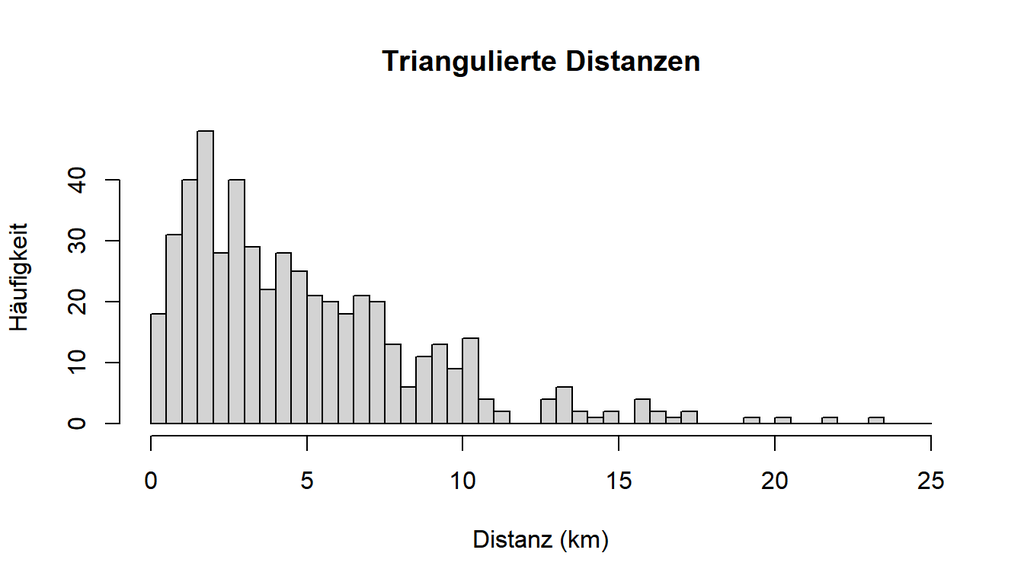

```r
hist((dist/1000)[dist<25000], breaks=seq(0,25,0.5),
     main='Triangulierte Distanzen', xlab = 'Distanz (km)', ylab = 'Häufigkeit')
```

Der vorangehende Code rechnet die Meter-Distanzen in Kilometer um (l/1000), zuvor wird auf Distanzen unter 25000 m gefiltert ([dist<25000]). Die Schrittweite (*breaks*) wird als Sequenz (seq()) von 0 bis 25 km mit Intervallen von 0,5 km festgelegt. Abschließend werden noch der Titel und die Beschriftungen der x- und y-Achse hinzugefügt. Vergrößern wir das Intervall auf 1 km entfällt die visuelle Trennung zwischen 1,5 km und 3 km und es bleibt ein leichter Absatzt im Verlauf mit geringer Häufung von Distanzen bei 5 km. Es folgen unscharfe Häufungen bei den Vielfachen von 5 km. Das Histogramm weist auf Agglomerationen von Talaiots in einem Abstand von bis zu 3 km hin, diese könnten sich dann in Abständen von ca. 5 km wiederholen. Dazwischen klaffen aber auch Lücken, die wegen des Vielfachen von 5 km möglicherweise durch fehlende Gruppen verursacht worden sein könnten. Letzteres ist lediglich aus der Wiederholung der Distanz abgeleitet und kann auch andere Gründe haben.

# 7 Rasterdaten

## 7.1 Einleitung

Rasterdaten stellen eine deutlich anders gestaltete Datenform als Vektordaten dar. Grundlage ist eine Rasterzelle mit definierter Dimension, die jeweils einen Wert repräsentiert. Jede Zelle liegt orthogonal im Koordiatensystem und ist quadratisch, lediglich Surfer nutzt auch rechteckige Zellen. Die Definition eines flächigen Datenbestandes ist damit recht einfach möglich, impliziert aber zugleich ein größeres Datenvolumen gegenüber Vektordaten. Stark heterogene Werte wie Höhenangaben werden effizienter und deshalb öfter als Raster dargestellt. Im Unterschied werden lineare Strukturen oder Flächen, z.B. Flüsse oder Bebauung, als Vektoren effizienter abgebildet. Hinzu kommen eingescannte Pläne, die Linien zeigen aber nur als Raster vorliegen.

Rasterdaten liegen oft als GeoTIF vor. Wesentlicher Unterschied zum “normalen” TIF ist 1. der veränderte Wertebereich der Zellen, so sind auch negative Zahlen möglich, und 2. die implizite Information zur geographischen Lage. Ein alternatives Format ist das GRD-Format, dieses kann als Text oder auch binär kodiert vorliegen.

Die Werte der Rasterzellen können mit benachbarten Zellen des selben Rasters oder mit überlagernden Zellen anderer Raster verrechnet werden. Damit lassen sich viele neue Modelle und abgeleitete Daten erstellen, so z.B. Hangneigung, Exposition oder Abflussmodelle.

## 7.2 Fallbeispiel

Das Fallbeispiel für Rasterdaten ist eine kleine geomagnetische Prospektion auf dem Fundplatz von Closos de Can Gaià bei Portocolom auf Mallorca (39.4191°N, 3.2443°E). Der Fundplatz ist einer der wenigen auf Mallorca mit mehreren schiffsförmigen Wohnbauten der Bronzezeit (Navetas), die hier in einfacher, doppelter und sogar dreifacher Ausführung vorkommen. Die Prospektion erfolgte 2010 im Rahmen eines ERASMUS-Austausches. Über die Jahre haben auf diesem Fundplatz zahlreiche Untersuchungen stattgefunden Frey und Rosselló Bordoy (1966); Servera (2005); Belenguer Arias und Matas Gallardo (2005); Fornés u. a. (2009); Rinne und Salvà Simonet (2012); Rinne und Salvà Simonet (2013); Picornell-Gelabert und Servera-Vives (2017). Der Fundplatz ist heute mit Informationstafeln touristisch erschlossen und kann frei begangen werden.

Die geophysikalische Prospketion erfolgte mit einem 1-Sonden-Gradiometer (Bartington) in Feldern von *a priori* 10 m Kantenlänge und einer Messdichte von 0,25 m auf 0,125 m entlang ausgelegter Maßbänder. Die Felder sind aufgrund der dichten Vegetation, überwiegend Macchie, stark gegliedert. Damit ist auch die gesamte Beurteilung beeinträchtigt. Die abschließende Einmessung der Felder konnte nur mit einem einfachen GPS erfolgen, hierfür wurden alle Feldkanten und ein Teil der benachbarten Straße mit einer hohen Messdichte (1 Hz) langsam abgeschritten. In Kombination mit den Luftbildern [IDEIB](https://ideib.caib.es/visor/) kann die abschließende Lagegenauigkeit der Prospektionsfelder auf unter 1 m geschätzt werden.

Die Daten für diese Übung liegen vor:

- pp_magnetik_2010.txt: Feldecken als Liste mit Feldnummer, Rechts- und Hochwert (EPSG: 25831) als TAB-getrennte Spalten.
- closos_1.grd, … : Felder 1 bis 4 als Surfer Grid (Textformat) mit lokalen Koordinaten und einer Interpolation der ursprünglichen Messwerte auf 0,10 x 0,10 m.

Zudem werden folgende WMS (*web map services*) des IDEIB für Luftbilder von 1956 und heute genutzt. Diese Serveradressen können sich ändern, einen Katalog mit Rechercheoption finden sie [hier](http://ideib.caib.es/cataleg/srv/cat/catalog.search#/home):

- 2021: https://ideib.caib.es/geoserveis/services/imatges/GOIB_Ortofoto_2021_IB/MapServer/WMSServer?request=getCapabilities&service=wms
- 1956: https://ideib.caib.es/geoserveis/services/imatges/GOIB_Ortofoto_1956_IB/MapServer/WMSServer?request=GetCapabilities&service=WMS

Laden Sie Bitte als erstes die Punktliste pp_magnetik_2010.txt. Öffnen Sie dazu den Data Source Manager (<strg> + <l>), wählen Sie “Getrennte Text” und setzen Sie nachfolgend die notwendigen Parameter. Danach zoomen Sie bitte auf diese Punkte, z.B. über das Kontextmenü. Wählen Sie für die spätere Unterscheidung der Felder eine kategorisierte Symbologie auf Basis der Spalte “FeldNr”.

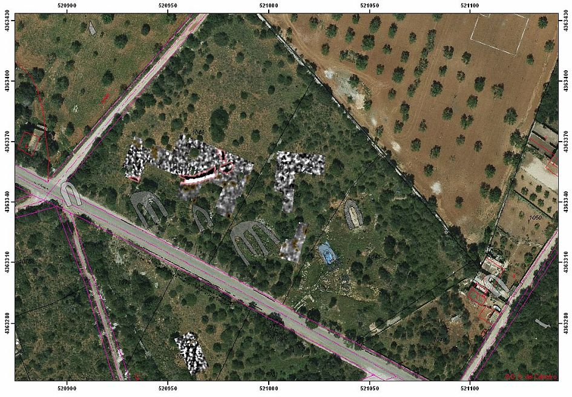

Closos Can Gaià. Stukturen nach Frey und Rosselló Bordoy (1966, Abb. 7) und Ergebnisse der geophysikalischen Prospektion von 2010 (Kartengrundlage: IDEIB, EPSG: 25831).

## 7.3 Exkurs Punkte zu Linie und Polygon

Um aus zahlreichen Punkten diverser Felder jeweils ein zugehöriges Polygon zu erstellen könne Sie die Funktion *ST_ConvexHull()* nutzen. Im vorliegenden Fall werden die unregelmäßigen Felder 2 und 3 aber nicht schön dargestellt.

```sql
select FeldNr, ST_ConvexHull(ST_Collect(geometry)) as geom
from pp_magnetik_2010 group by 1;
```

Sind die Punkte sinvoll sortiert, kann eine Linie erstellt werden, allerdings ohne den Anschluss zum Startpunkt.

```sql
select feldnr, MakeLine(geometry) as geom
from pp_magnetik_2010
group by 1;
```

Soll aus den Punkten ein Polygon erstellt werden, muss der erste Punkt (*ST_PointN()*) als letzter Punkt (Option ‘-1’ bei *ST_AddPoint()*) zum Schließen der Linie ergänzt werden, um dann ein Polygon zu erstellen. Messpunkte von Befunden aus einem Tachymeter können analog verarbeitet werden.

```sql
select feldnr,
       ST_MakePolygon(
         ST_AddPoint(MakeLine(geometry),
                     ST_PointN(MakeLine(geometry), 1),
                     -1)
       ) as geom
from pp_magnetik_2010
group by 1;
```

## 7.4 WMS - Web Map Services

Sie finden Daten wie das verwendete Höhenmodell nicht nur zum *download* im Internet sondern auch als interaktive Webdienste. Besonders weit verbreitet sind WMS für Rasterdaten, z.B. Karten oder Orthofotos, und WFS (*web feature services*) für Objektdaten. Für die Nutzung müssen Sie die Serveradresse des Dienstes bei QGIS eintragen, ggf. ergänzt um eine Anmeldeinformation für den Server. Nach dem Einbinden des Dienstes in das Projekt wird bei jeder Aktualisierung des Bildschirmes, z.B. zoomen, eine Anfrage an der Server gestartet und der benötigte Ausschnitt heruntergeladen. Dies impliziert eine gute Netzwerkanbindung und ggf. Wartezeit.

WMS-Dienste tragen Sie über den *Data Source Manager* (<strg> + <l>) ein. Wählen Sie im zugehörigen Fenster [Neu], übertragen Sie die URL aus der Datenliste (s.o.) in das entsprechende Feld, vergeben Sie einen strukturierten Namen, z.B. SP-IB-OrthoFoto20218 oder SP-IB-OrthoFoto1956 und bestätigen Sie mit [OK]. Nachdem Sie den Dienst eingetragen haben wählen Sie [Verbinden], im Reiter “Teilsets” können Sie je nach Dienst einzelne Elemente markieren und gezielt hinzufügen. Für die Luftbilder gibt es jeweils nur ein Element, welches Sie bitte hinzufügen.

**WMS-Karten können in QGIS lokal gespeichert werden**. Wählen Sie hierfür aus dem Kontextmenü des jeweiligen Layers “Exportieren -> Speichern als” und neuen Fenster “Rasterlayer speichern unter…” tragen Sie folgende Parameter ein: Ausgabemodus: Rasterrohdaten, Format: GeoTIFF, deaktivieren Sie für diesen Fall “VRT erzeugen”, wählen Sie einen Speicherort und Dateinamen, KBS: 25831, Ausdehnung: [Kartenausschnittausdehnung], Auflösung: jeweils 0.2 (beachte Sie die Anzahl der abhängigen Spalten und Zeilen) und bestätigen Sie abschließend mit [OK]. Anschließend steht der gewählte Kartenauschnitt lokal zur Verfügung, die weitere Arbeit wird damit 1. etwas schneller und 2. können die Daten im Rasterrechner genutzt werden.

| Anmerkungen |
| --- |
| Server begrenzen üblicherweise die Anzahl und den Umfang der Zugriffe. |
| VRT steht für *Virtual Raster Tile* und ist eine XML-Datei zur Kombination zahlreicher Rasterkacheln (s. [GDAL](https://gdal.org/drivers/raster/vrt.html)). |

## 7.5 Georeferenzieren

Neben digitalen Primärdaten (Höhenmodell, Luftbild, geophysikalische Messdaten) liegen oft Altdaten in Form eingescannter Pläne vor. Diese digitale Daten ohne geographischen Bezug müssen erst georeferenziert werden. Hierbei findet, je nach Anforderung, eine mehrstufige Veränderung über eine zunehmende Anzahl an Parametern statt. Bei der **Lineare Transformation** stehen Ausgangs- und Zielraster (Matrizen) über eine lineare Funktion in Beziehung. Hierbei übliche Transformationen sind das Skalieren und Schieben. Demnach ist diese Tranfsormation für orthogonale, in sich stimmige Rasterdaten wie Grabungspläne in einem lokalen Koordinatensystem geeignet. Die **Helmert Transformation** verändert die Daten über sieben Parameter, eine allgemeine Verschiebung des Ursprungs sowie Skalierung und Rotation für jede der drei Achsen des dreidimensionalen Raumes. Sie ähnelt damit der Linearen Transformation, behandelt die Achsen aber unabhängig und kann damit Verzerrungen ausgleichen. **Polynomiale Transformationen** liegen als Transformationen erster, zweiter und dritter Ordnung vor. Die erste Ordnung (affine) erlaubt gleichfalls Rotation, Verschiebung und Skalierung unter Beibehaltung der Proportion der Achsen. Die zweite Ordnung erlaubt auch Krümmungen und damit die Korrektur perspektivischer Verzerrungen von Luftbildern. Diese Transformation wird oft eingesetzt. Die weiteren Transformationen bieten komplexere Veränderungen der Daten bei geringerer Abweichung an den Referenzpunkten. Eine höhere Genauigkeiten der dazwischen oder am Bildrand liegenden Daten ist nicht zwingend gegeben.

### 7.5.1 Georeferenzierung in QGIS

QGIS bietet die Georeferenzierung von Rasterdaten mit vielfältigen Optionen und den vorgenannten Projektionen. Die Georeferenzierung befindet sich aktuell im Menü unter “**Layer -> Georeferenzierung**”. Aktivieren Sie vor der Georeferenzierung den **Fang** zum präzisen Markieren der Referenzpunkte über “Ansicht -> Werkzeugleisten -> Einrastwerkzeugleiste”. Damit erscheint ein Magnet-Icon in der Symbolleiste, über das Sie die notwendigen Einstellungen vornehmen können.

Im Fenster der Georeferenzierung öffnen Sie als erstes ein neues Raster (<strg> + <o>) und starten Sie mit **closos_1.grd**. Über “Einstellungen -> Quelleigenschaften” können Sie die Darstellung des Raster verändern, gerade bei Magnetikdaten kann dies für das Erkennen von Feldgrenzen und bei vorliegenden Leerwerten in den Feldecken hilfreich sein. Deaktivieren Sie für das vorliegende Raster unter Transparenz den “Leerwert”.

Unter “Einstellungen -> Transformationsparameter” werden die Transformationsparameter eingestellt. Diese sind für das geladene Raster:

- Transformationstyp: Polynomial 1.
- Abtastmethode: Es ist das Interpolationsverfahren für die neu zu berechnenden Zellen. “Nächster Nachbar” bewertet die Proximität und führt zu vergleichsweise härteren Kanten als “Kubisches Spline”. Die genuine Messung ist keine Punktmessung, sondern Ergebnis eines Messbereiches mit diversen magnetischer Feldern, Proximität und Intensität spielen hier gleichfalls eine Rolle. Jede Interpolation führt zu einer Veränderung der Daten und sollte deshalb kritisch hinterfragt werden. Wählen Sie “Nächster Nachbar”.
- Ziel-KBS: EPSG:25831.
- Ausgaberaster: Ein Name wird vorgegeben, kann aber geändert werden.
- Passpunkte speichern: Ist eher vorteilhaft.
- Falls nötig 0 für Transparenz verwenden: Ein wichtiger Punkt. Die “0” ist bei den vorliegenden Messwerten ein gültiger Wert und darf deshalb nicht als “Leerwert” definiert werden. Auch bei S/W- und Graustufenbildern ist “0” (Schwarz) ein gültiger Wert. Bei Farbbildern ist “0” für alle Kanäle eher selten und ein guter Wert für Fehlende Werte. In unserem Rasterdatensatz ist 1.70141e+38 als Leerwert bereits definiert, wählen Sie keine zusätzliche Transparenz.
- Zielauflösung setzen: Wird keine Änderung eingetragen, wird die Auflösung des Eingangsrasters gewählt.
- Wenn fertig in QGIS laden: Meist die gewünschte Aktion.

Wählen Sie nun “Bearbeiten -> Punkt hinzufügen” (<strg> + <a>) und markieren Sie nacheinander einen Punkt im Raster und dann den korrespondierenden Referenzpunkt in der Karte. Die Referenzpunkte in der Karte können in einem neuen Fenster wahlweise von Hand eingetragen oder mit [Aus Kartenansicht] in der Karte markiert und mit [OK] bestätigt werden. Wiederholen Sie den Vorgang für die vier Ecken, nutzen Sie beim Raster das Scrollrad der Maus zum Zoomen. Rote Linien zeigen die projektive Verschiebung der Punkte, dies kann ein Hinweis auf mögliche Fehler sein, irritiert bisweilen aber auch nur. Die additiv geführte Punktliste gibt berechnete Fehlerwerte aus und erlaubt das aktivieren oder deaktivieren einzelner Punkt. “Datei -> Georeferenzierunh starten” führt den Vorgang dann aus.

Mit dem Öffnen eines neuen Rasters (<strg> + <o>) oder dem Schließen des Fensters können die Messpunkte gespeichert werden. Wiederholen Sie den Vorgang für die verbleibenden Raster. Wählen Sie jeweils mindestens 3 Punkte. Beachten Sie, dass Feld 3 um 90° gedreht ist.

## 7.6 Rasterdaten & Rasterrechner

### 7.6.1 Magnetikdaten

Setzen Sie für alle vier Prospektionsflächen die Symbologie im Farbverlauf auf “Weiß nach Schwarz”, Min: -15, Max: +15 und Kontrastverbesserung: “Strecken auf MinMax”. Damit werden die verfügbaren 256 Graustufenwerte zwischen -15 nT (nano Tesla) und +15 nT verteilt, die jeweils außerhalb liegenden Werte werden Weiß oder Schwarz dargestellt.

Betrachten Sie die Flächen einen Augenblick, Sie erkennen unschwer die sehr heterogenen und kontrastreichen Daten im Norden und jenseits der Straße im Süden sowie die eher “weicheren” Werte zwischen den Navetas. Dies wird durch den Untergrund verursacht. Es handelt sich um Kalkstein in dessen zahlreichen Klüften und Kavernen toniges Sediment abgelagert ist. Der Kalk liefert kein, der tonige Boden ein deutliches Signal und im Ergebnis entsteht das von uns zu erkennende Bild. Im Umkehrschluss steht zwischen den Navetas der Kalkfelsen nicht unmittelbar an der Oberfläche an.

Vor allem im Feld 1 sind einige rundliche Anomalien eher positiver (dunkler) Messwerte zu erkennen. Markieren Sie bei den Layern das Messfeld 1 und prüfen Sie die Messwerte mit der Objektabfrage (i[nfo]-Icon) aus der Menüleiste. Die Messwerte liegen überwiegend zwischen 7 und 16 nT nur bei der Anomalie mit weißem Rand werden 50 nT erreicht.

**Aufgabe**: Wir vermuten potentielle Gruben bei 7 nT bis 16 nT und wollen diese hervorheben. Ziel ist es, alle Messwerte in diesem Bereich auf “1” (Wahr) zu setzen, alle anderen auf nicht definiert. Damit ist nachfolgend auch die Vektorisierung der herausgestellten Strukturen möglich. Starten Sie den **Rasterrechner** (“Raster -> Rasterrechner”). Oben links haben Sie die verfügbaren Layer und jeweils vorhandenen Bänder (Farbkanäle), oben rechts notwendige Parameter und unten viel Platz für die Berechnungsformel.

Fügen Sie mit einem Doppelklick das Band 1 des Messfeldes 1 zum Ausdruck hinzu (closos_1_modifiziert@1). Tragen Sie oben rechts den Namen für die Ausgabedatei ein, z.B. closos_1_7-16nT. Für die Ausdehnung dieser Datei klicken Sie auf [Gewählte Layerausdehnung] und das entsprechende KBS der Ursprungsdatei oder des Projektes.

Für die Version ab 3.22 gibt es die [IF]-Bedingung mit folgender Syntax: if (Bedingung, wenn WAHR, wenn FALSCH). Für die Messwerte der potentiellen archäologischen Befunde ergibt sich somit folgende Anweisung: `if (("closos_1_modifiziert@1">6) and ("closos_1_modifiziert@1"<17), 1, 1/0)`. Der Wert für FALSCH ist die ungültige Division durch 0, die aber leider nicht NULL sondern mit -3,40282e+38 als Standartwert für ein Leerfeld (*no data value*) zurückgegeben wird. Das ist Konsequent, denn Löcher darf es in einem Raster nicht geben. Bei der nachfolgenden Konvertierung des Rasters in eine Vektordatei wird daraus also stets ein gültiges Polygon.

Der Rasterrechner vor Version 3.22 kannte keine *if-than-else*-Syntax. Die Rückgabe der zu prüfenden Bedingung ist “1” für WAHR und “0” für FALSCH. Mit einer geschickten Kombination von Multiplikation oder Division kann die entsprechende Wenn-Dann-Berechnungen gebaut werden. Im folgenden Fall z.B. die Division durch 0 = ungültig (**Zeilenumbruch bitte entfernen**):

```
(("closos_1_modifiziert@1">6) and ("closos_1_modifiziert@1"<17)) /
(("closos_1_modifiziert@1">6) and ("closos_1_modifiziert@1"<17))
```

Schreiben Sie das Ergebnis nicht in einen temporären Layer, die nachfolgend genutzte **Funktion Raster-zu-Polygon** kann in meiner Version (3.22.12) **temporäre Layer nicht verarbeiten**.

Wählen Sie für den neuen Layer bei der Symbologie bitte “Paletten-/Eindeutige Werte”, [Klassifizieren] und [OK]. Führen Sie das gleiche auch für Fläche 3 durch. *Markieren Sie links den richtigen Layer bevor Sie rechts [Gewählte Layerausdehnung] auswählen!* Das Bild ist deutlich heterogener und zeigt, dass dieses pauschale Verfahren Grenzen hat. Mein weiterer *workflow* ist dann Vektorisieren, Umfang und Wurzel der Fläche ins Verhältnis setzen (sqrt(a)/U), um die Regelhaftigkeit der Anomalie bewerten zu können, Zonenstatistik (s. Werkzeugkiste) für jede Anomalie zu den Rasterwerten des Magnetikbildes berechnen lassen und abschließend auf Grundlage dieser Werte entscheiden, ob ein Befund vorliegt oder nicht.

| Anmerkung |
| --- |
| Wenn **Fehler** auftreten prüfen Sie bitte als erstes die Layernamen, *copy & paste* kann die Ursache sein. |
| Prüfen Sie dann die Ausdehnung des neu zu berechnenden Rasters, auch dies wird gerne vergessen. |

### 7.6.2 Luftbilder und Vegetation

Augenscheinlich hat die Vegetation im Bereich der Fundstelle seit 1956 deutlich zugenommen. Das ist ein “alter Hut” und hängt mit den fehlenden Schaf- und Ziegenherden zusammen. Ich möchte diese Erkenntnis nachvollziehbar quantifizieren. Wir müssen also bei dem Orthofoto von 1956 die sehr dunklen bis schwarzen Pixel zählen (Schwellwert sei <50) und hieraus die Fläche ableiten. Bei dem Farbfoto die eher grünen Flächen (RGB = Rot, Grün, Blau). Der erste Fall ist nach der vorangehenden Übung trivial, lösen Sie den bitte eigenständig. Der zweite Fall braucht etwas Denksport und einfache Farbenlehre. Falls Sie mein erster schneller Ansatz interessiert:

```
("orthoaktuell@2" > "orthoaktuell@1") and ("orthoaktuell@2" > "orthoaktuell@3")
```

Da die Division mit 0 nicht NULL liefert, sondern den sehr hohen Standardwert für *no data value* spare ich mir das if(), denn der Rückgabewert einer Bedingung ist ja schon 1 und 0. Die Bedingung ist recht schlicht, der Grüne Kanal (@2) soll stets größer als die anderen sein. Suchen Sie in der Werkzeugkiste nach “**Bericht eindeutiger Rasterwerte**” und führen diesen auf das neue Raster aus. Der Bericht wird als temporäre HTML-Datei für den Browser abgelegt, der Pfad dazu wird sowohl im Protokoll als auch als Hypelink angezeigt. Dort finden Sie die Liste der Zellwerte, deren Anzahl und die aus der Pixelgröße resultierende Fläche.

Erstellen Sie eine Layergruppe “Vegetation Orthofotos” und fügen Sie diese Layer ein.

Anmerkung: Ich verwende das Resultat im nächsten Abschnitt zur Kartenerstellung und verzichte deshalb an dieser Stelle auf eine Abbildung.

# 8 Karte erstellen

In QGIS gibt es neben den **Karten (Layout)** auch Berichte. Ein **Bericht** kombiniert Karten, Text, Grafik, Tabellen, etc. Im Wesdentlichen ist ein Bericht ein erweitertes Layout, wie es mit der Kombination von einer Karte und der selektiven Darstellung einer Attributtabelle auch im Layout schon immer möglich war.

## 8.1 Einleitung

Neben der Analyse sind Karten (Layouts) ein ganz wesentliches Element der Arbeit mit einem GIS und grundlegend für die Darstellung von Sachverhalten oder die Vermittlung unserer Ergebnisse. Dabei kommen vier wichtige Aspekte mit sehr unterschiedlichen Anforderungen zum Tragen:

1. Unser fachlicher Anspruch,
2. die kartografischen Standards,
3. der grafische als auch ästhetische Anspruch und
4. die redaktionellen Vorgaben.

Gute Karten sind eine zeitintensive Herausforderung.

### 8.1.1 Fallbeispiel

Als Fallbeispiel wähle ich nachfolgend den Fundplatz von Closos de Can Gaiá bei Portocolom auf Mallorca (39.4191°N, 3.2443°E). Ein erstes Aufmaß erfolgte durch ein Grabungsteam der Uni Marburg neben deren eigentlichen Arbeiten in der Siedlung von S’Illot (Frey und Rosselló Bordoy (1966)). Die damalige Vermessung wurde durch den Neubau der Straße und den weiteren Landesausbau notwendig, dem bereits ein Teil des Fundplatzes zum Opfer gefallen war. Neben den damals erkannten Baustrukturen ist nach dem Luftbild von 1956 mindestens eine weitere Naveta auf der Straßenkreuzung wahrscheinlich (Hinweis B. Salvà). Der Fundplatz ist heute mit Informationstafeln touristisch erschlossen und kann frei begangen werden.

Die Daten für diese Übung liegen vor:

- Frey und Rosselló Bordoy (1966), Abb. 7 (georeferenziert anhand der Luftbilder und in Umrissen digitalisiert),
- das Orthofoto von 2021 (s. Kapitel Rasterdaten),
- die im vorangehenden Kapitel erstellten Vegetationskarten und
- die Comarcas der früheren Übung als Umrisskarte für eine kleine Übersichtskarte.

### 8.1.2 Ziel der Darstellung

Meine Karte soll den Funplatz und seine Denkmalgeschichte darstellen. Ich möchte dafür sowohl die 1966 publizierten Navetas als auch die natürlichen Veränderungen in der Vegetation seit dieser Zeit darstellen. Als Kartengrundlage wähle ich das aktuelle Luftbild, überlager es mit den nachgezeichneten und beschrifteten Navetas und ergänze die Vegetationsraster des vorangehenden Kapitels.

## 8.2 Karte erstellen

Für ein Projekt können viele Layouts in unterschiedlichen Formaten entworfen und mit den jeweils sichtbaren Layern “eingefroren” werden. Es ist also möglich, diverse Arbeitsstände in einem Projekt als Abbildung vorzuhalten. Die Verwaltung und Erstellung erfolgt über “Projekt -> Layout Verwaltung”. Hier können Sie mit “Leeres Layout” [Erzeugen] ein neues Layout erzeugen. Ich nenne meine Vorlage ‘Vegetation-DinA4R’

### 8.2.1 Vorbereitung im Projektfenster

Für die Darstellung der Navetas wähle ich eine kategorisierte Farbgebung nach dem Feld tipo, um nach den sicheren (dunkelgrau) und nur vermuteten (hellgrau) Navetas zu differenzieren. Die **Beschriftung der Navetas** richtet sich nach der Namengebung von 1966. Da in diesem Plan nicht alle Strukturen beschriftet sind, wähle ich für den **Wert** nicht ein einzelnes Feld aus, z.B. “Name”, sondern eine *if*-Bedingungen:

```
if ("Name" is  not null, "Name", "tipo")
```

Damit wird der Name angezeigt, sofern einer vorliegt, ansonsten der Typ. Der schwarze Text ist auf dem bunten Hintergrund kaum lesbar. Ich wähle deshalb als **Hintergrund** ein weißes Rechteck. Alternativ kann auch ein Puffer gewählt werden.

Die Position der Schrift in der Mitte der Naveta stört mich sehr, dies können wir im Unterpunkt *Platzierung* ändern. Ich wechsel von “Um Zentroid” zu “**Abstand vom Zentrum**”. Die Zuweisung der Position nach Quadranten um das Zentrum reicht nicht, deshalb wähle ich den “X, Y Versatz”. Eine feste Größe von 12 m für y wird den sehr unterschiedlichen Größen der Navetas nicht gerecht. Aus diesem Grund wähle ich aus dem *dropdown* am rechten Rand mit “Bearbeiten” zum **Ausdruckseditor** und ergänze: `concat('0,',bounds_height($geometry)*0.8)`.

Das erwartete Format ist eine Zeichnekette mit zwei, durch ein Komma getrennten Distanzwerte für x und y (x.x, y.y). Ich starte mit dem zweiten, dem y-Wert: Dieser soll abhängig von der Geometriehöhe sein (*bounds_height($geometry)*), die halbe Höhe (y-Achse) reicht aber nicht, deshalb wähle ich 80% der Höhe. Eine Verschiebung auf x ist nicht nötig, also ‘0,’ und beide Ausdrücke werden mit *concat()* zu einer Zeichenkette verbunden.

### 8.2.2 Elemente der Karte

Die Gestaltung des Layout erfolgt in einem neuen Fenster mit umfangreichen Icon-Leisten (abhängig von den Einstellungen unter “Ansicht”), einem leeren Blatt im größten Teil des Fensters und den Eigenschaften des aktiven Elementes am rechten Rand. Um die Papiergröße und -ausrichtung nachträglich zu verändern müssen Sie 1. im Kontextmenü zum Papier die **Seiteneigenschaften** wählen, die Sie dann 2. rechts auf dem Reiter zu den Elementeigenschaften anpassen können. “Layout -> Seiteneinstellungen” hat an dieser Stelle keine Auswirkung. Elemente im Layout werden rechts oben unter dem Register **Elemente** aufgeführt und können hier u.a. umbenannt werden. Dies ist bei vielen Elementen und Detailkarten sehr hilfreich.

Wechseln Sie rechts auf den Reiter **Führungen** und ergänzen Sie als erstes horizontale Führungen bei 20 mm, 160 mm und 190 mm sowie vertikale Führungen bei 20 mm und 277 mm.

### 8.2.3 Karte hinzufügen

Unter dem Menüpunkt “Element hinzufügen (a)” können Sie eine “Karte hinzufügen” auswählen und mit der Maus aufziehen (Icon: Papierrolle mit grünem Plus). Ist diese Karte markiert, können Sie rechts im Fenster unter dem Reiter **Elementeigenschaften** alle Eigenschaften verändern:

Setzen Sie unter **Haupteigenschaften** den Maßstab auf 1000. Unter **Layer** folgt die Option, die dargestellten Layer und auch die Layerstile zu sperren. Wenn alle Layer wie gewünscht angezeigt werden, sperren Sie beide Optionen: Layer und Stile. In der Folge werden Änderungen im Projekt im Layout dieser Karte nicht wirksam. Die **Ausdehnung** der Karte mit Zahlen zu beschreiben, ist mühevoll, verwenden Sie dazu lieber “Bearbeiten -> Inhalt verschieben” (Icon: Papierrolle mit blauen Pfeilen). Ist dieses Icon aktiv, kann der Karteninhalt verschoben werden. Wählen Sie das Icon mit dem Mauszeiger, um erneut andere Elemente auszuwählen.

| Anmerkung |
| --- |
| Die Elemente im Eigenschaftenfenster haben viele Unterebenen. Mit dem blauen Pfeil am oberen Rand unter dem Reiter “Elementeigenschaften” gelangen Sie wieder auf die jeweils obere Ebene. |

Sie können für eine Karte mehrere **Gitter** definieren. Fügen Sie mit dem grünen Plus ein neues Gitter hinzu (Gitter 1). Mit einem Doppelklick auf den Namen können Sie diesen auch ändern. Wählen Sie [Gitter ändern]. Es folgen Unterbereiche zu: Erscheinungsbild, Rahmen und Koordinaten zeichnen. Für **Erscheinungsbild** setzen Sie als erstes das Intervall für x und y auf ‘50’. Probieren Sie nachfolgend die Optionen unter “Gittertyp” und treffen Sie eine Entscheidung. Ich selbst verwende bisweilen “Kreuz”, reduziere aber die Kreuzgröße und Linienstärke in den folgenden Feldern. Ich verwende oft “Nur Rahmen und Beschriftung”. Der **Rahmen** ist ein wichtiges Element, beschriftet informiert er über den Maßstab und die absolute Lage der Karte. Breite schwarze Ränder erinnern an Trauerkarten und liefern sonst aber keine Information. Ich wähle “Äußere Markierungen”, Rahmengröße: 1 mm und Rahmenlinienstärke: 0,12 mm. Ich aktiviere **Koordinaten zeichnen**, setze links und rechts auf “Vertikal aufsteigend” und die Koordinatengenauigkeit auf “0” Nachkommastellen, Schriftart (neue Ebene) auf 8 pt, mit dem blauen Pfeil oben zurück zum Gitter und Abstand zum Kartenrahmen auf 1 mm. Wechseln Sie mit dem Pfeilsymbol nach links am oberen Rand dieses Bereiches wieder in die übergeordnete Instanz der Elementeigenschaften. Anmerkung: Die Karte ragt nun über die Führungslinien hinaus und muss angepasst werden. Achten Sie dabei auf den Maßstab!

Abschließend aktivieren Sie die Option **Rahmen**, reduzieren aber die Dicke auf 0,15 mm. Wählen Sie Ihren Kartenausschnitt nach dem Inhalt aber auch nach den Koordinaten, diese sollten nicht über den Rand hinauslaufen, sondern sich harmonisch um die Karte verteilen. Arbeiten Sie ggf. mit einem Versatz der Gitterintervalle.

Sperren Sie nun Layer und Stile dieser Karte.

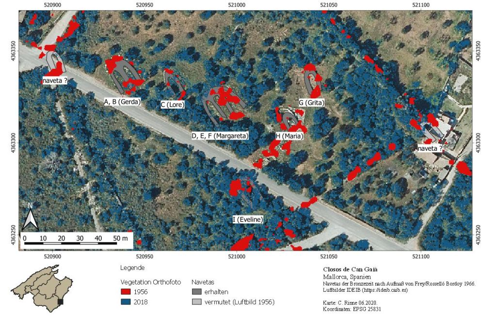

Closos de Can Gaià. Stukturen nach Frey und Rosselló Bordoy (1966, Abb. 7) und Vegetationsdichte nach Luftbildern (Kartengrundlage: IDEIB, EPSG: 25831).

### 8.2.4 Übersichtskarte hinzufügen

Zuerst wechseln Sie in das Projekt, blenden die zuvor dargestellten Layer zum Fundplatz “Closos de Can Gaià” aus und nur den Layer “comarcas” als grau gefüllte Polygone für die Darstellung der Insel ein. Im Layout füge ich eine neue, deutlich kleinere Karte als Übersichtskarte links unten hinzu. Den Maßstab setzen ich auf “3000000”, so dass die gesamte Insel Sichtbar ist. Da es sich für mich um ein grafisches Element handelt verzichte ich auf einen Koordinatenrahmen. Dieses Element ist automatisch als “Karte 2” bezeichnet worden.

Bei den Elementeigenschaften ergänze ich unter **Übersichten** eine neue Übersicht, wähle unter Kartenrahmen: Karte 1 (meine erste große Karte) und sehe vorerst nichts wegen der großen Maßstabsdifferenz und dem aktuellen Rahmenstil. Klicken Sie auf das Farbfeld für den Rahmenstil, Sie erkennen das übliche Layout der Symbologie. Markieren Sie das Unterelement “Einfache Füllung”. Wählen Sie unterhalb für Füllfarbe und Strichfarbe: Schwarz, Strichbreite: 3 mm, Strichstil: Durchgezogene Linie und Verbindungsstil: Eckig. Mit dem blauen Pfeil nach links am oberen Rand dieser Elementeigenschaften verlassen Sie die Symboleigenschaft. Sperren Sie auch hier Layer und Stile.

### 8.2.5 Legende hinzufügen

Markieren Sie die Karte 1 und wählen Sie nachfolgend “Elemente hinzufügen (a) -> Legende hinzufügen). Ziehen Sie die Legende im mittleren Bereich des Layouts auf. Auch für dieses Element können Sie rechts unten die Parameter editieren.

Die **Legendenelemente** werden *a priori* automatisch verwaltet und entsprechen den aktiven Layern des Projektes. Deaktivieren Sie diese Option und Sie können nachfolgend die Einträge editieren, entfernen oder ergänzen. In unserem Fall sehen die Einträge zur Vegetation unschön aus. Die Gruppenüberschrift “Vegetation Orthofotos” belassen Sie. Die beiden Rasterkarten werden neben dem Legendeneintrag auch mit dem Kanal beschriftet. Markieren Sie Kanal 1 und entfernen Sie diesen Text mit dem [-]-Icon. Ändern Sie den Unterpunkt von “1” zu “1956: 17500 m²”. Rufen Sie das Kontextmenü zum Layernamen auf und wählen Sie “[] Verstecken”, der Layername wird dann ausgeblendet. Verfahren Sie für den Layer von 2018 identisch, jedoch mit dem Eintrag “2018: 57536 m²”.

Ändern Sie für die Legende bitte noch folgende Parameter: Schriftarten: alle 10 pt, Spalten: 2, Symbol: Größe 5 mm x 3 mm, Zwischenräume: Spaltenabstand auf 6 mm.

### 8.2.6 Grafische Elemente

Fügen Sie einen **Maßstab** hinzu. Verringern Sie bei diesem die Leistenhöhe auf 1 mm und wählen Sie “Rechts 5” Segmente. Dadurch erhalten Sie links und rechts jeweils einen schwarzen Balken als Abschluss und die Breite entspricht auch der Unterteilung des Rahmens. Passen Sie ebenfalls die Textgröße an den Stil der Legende oder des Rahmens an.

Ergänzen Sie noch einen Nordpfeil, dies ist ein Unterpunkt des Menüs “Element hinzufügen (a)”. Wie das vorgenannte Element “Maßstab” handelt es sich um eine spezifische Information zu einer Karte, es muss also eindeutig zugewiesen sein. Am einfachsten ist es, beides auf der jeweiligen Karte abzulegen.

### 8.2.7 Textinformation

Es fehlen noch wichtige Textinformationen, z.B. Titel, Untertitel/Erläuterung, Autor, Jahr, Koordinatensystem und ggf. Quellenangaben. Diese Informationen sind natürlich auch abhängig von Inhalt und Darstellungskontext. Text wird als Beschriftung eingefügt und hat jeweils einen Textstil. Alternativ können Sie den Text als HTML darstellen und mit entsprechenden Auszeichnungen (*tags*) arbeiten. Nachfolgend dazu ein Beispiel:

[output not shown]

Zur Erläuterung:

- <b> …</b> : bold / fett
- <br> : break / Zeilenumbruch
- <small> … </small> : klein

Gehen Sie in den eingefügten Text, fügen Sie vor “Karte: …” eine Leerzeile ein und wählen Sie nun [Dynamischer Text] Karteneigenschaften > Karte 1 > Maßßstab. Verändern Sie den automatisch eingetragenen Text wie folgt:

`[%concat('M 1 : ', round(item_variables('Karte 1')['map_scale'],0))%]`

Die Vorschau sollte nun “M 1 : 1000” oder ggf. einen anderen Maßstab anzeigen. Von Innen nach Außen sind es folgende Schritte: 1. Die Abfrage des Maßstabes der ‘Karte 1’. 2. Die Rückgabe wird gerundet auf 0 Stellen: round(<Wert>,<Stellen>). 3. Mit ‘M 1:’ zusammengesetzt: concat(<Text1>, <Text2>, …) und die “[%…%]” Wandeln die Funktion in ein Textelement um, bzw. andersrum, in dem Text wird damit ein Funktionsbereich definiert. Der Maßstab wird nicht sofort angepasst aber bei weiteren Aktivitäten wie z.B. beim Drucken.

### 8.2.8 Attributtabelle

Ein interessanter Aspekt ist das Hinzufügen einer Attributtabelle im Layout. Hier können Sie sowohl die Spalten auswählen als auch bestimmen, ob alle oder nur die Daten zu den sichtbaren Objekten gelistet werden sollen.

# Literatur

Belenguer Arias, C., Matas Gallardo, F., 2005. La indústria òssia dels Closos de Can Gaià. Mayurqa: revista del Departament de Ciències Històriques i Teoria de les Arts 263–288.

Christaller, W., 1933. Die zentralen Orte in Süddeutschland : eine ökonomisch-geographische Untersuchung über die Gesetzmäßigkeit der Verbreitung und Entwicklung der Siedlungen mit städtischen Funktionen. G. Fischer, Jena.

Cziesla, E., 1990. Siedlungsdynamik auf steinzeitlichen Fundplätzen. Methodische Aspekte zur Analyse latenter Strukturen, Studies in Modern Archaeology. Bonn.

Eggers, H.J., 1986. Einführung in die Vorgeschichte, 2. ed. Piper, München.

Fornés, J., Javaloyas, D., Salvà Simonet, B., Belenguer, C., Mates, F., Servera, G., Oliver, L., 2009. Más que una casa. Los navetiformes de la Edad del bronce balear, in: Belarte, M.C., Reunió Internacional d’Arqueologia de Calafell (4 ; Calafell, E.;.2007). (Hrsg.), L’espai domèstic i organització de la societat a la protohistòria de la Mediterrània occidental (1er mil$\cdot$leni aC) : actes de la IV Reunió Internacional d’Arqueologoa de Calafell (Calafell - Tarragona, 6 al 9 de març de 2007), Arqueo mediterrània. Departament de Prehistòria, Història Antiga i Arqueologia de la Universitat de Barcelona, Barcelona, S. 323–330.

Frey, O.-H., Rosselló Bordoy, G., 1966. Navetas von Es Closos De Can Gaià auf Mallorca. Madrider Mitteilungen 7, 79–88.

Frey, O.-H., Rosselló Bordoy, G., 1964. Eine Talayot-Siedelung bei S’Illot, Mallorca. Madrider Mitteilungen 5, 55–71.

Guerrero Ayuso, V.M., Calvo Trias, M., Gornés Hachero, S., 2006a. Historia de las Islas Baleares 2. Mallorca y Menorca en la Edad del Hierro. Cultura Talayótica y Posttalayótica. El Mundo, Palma de Mallorca.

Guerrero Ayuso, V.M., Calvo Trias, M., Gornés Hachero, S., 2006b. Historia de las Islas Baleares 1. El poblamiento prehistórico de las Islas Baleares. Desde los orígenes al fin de la Edad del Bronce. El Mundo, Palma de Mallorca.

Haggett, P., 1973. Einführung in die kultur- und sozialgeographische Regionalanalyse. de Gruyter, Berlin.

Herzog, I., 2013. Berechnung von optimalen Wegen am Beispiel der Zeitstraße. Archäologische Informationen 31, 67–96. https://doi.org/10.11588/ai.2008.1&2.11119

Herzog, I., 2007. Simulationsexperimente zur Siedlungsdichte, in: Burmeister, H., Derks, S., Richthofen, J. von (Hrsg.), Zweiundvierzig. Festschrift für Michael Gebühr zum 65. Geburtstag, Internationale Archäologie : Studia honoraria. Marie Leidorf, Rahden/Westf., S. 3–14.

Ihm, P., 1978. Statistik in der Archäologie, Archeo-Physika. Rheinland, Köln.

Jankuhn, H., 1977. Einführung in die Siedlungsarchäologie. Berlin.

Kessler, H.<Graf>., 2010. Das Tagebuch / Harry Graf Kessler. Hrsg. von Roland S. Kamzelak Bd. 9 1926 - 1937, Veröffentlichungen der Deutschen Schillergesellschaft. Cotta, Stuttgart.

Knitter, D., Günther, G., Hamer, W.B., Keßler, T., Seguin, J., Unkel, I., Weiberg, E., Duttmann, R., Nakoinz, O., 2019. Land use patterns and climate change - a modeled scenario of the Late Bronze Age in Southern Greece. Environmental Research Letters 14, 125003. https://doi.org/10.1088/1748-9326/ab5126

Kunow, J., Müller, J., Schopper, F. (Hrsg.), 2007. Archäoprognose Brandenburg II, Forschungen zur Archäologie im Land Brandenburg. Brandenburgisches Landesamt für Denkmalpflege und Archäologisches Landesmuseum, Wünsdorf.

Linke, W., 1976. Frühes Bauerntum und geographische Umwelt. Eine historisch-geographische Untersuchung des Früh- und Mittelneolithikums westfälischer und nordhessischer Bördenlandschaften, Bochumer Geographische Arbeiten. Paderborn.

Lull, V., Micó Pérez, R., Palomar Puebla, B., Rihuete Herrada, C., Risch, R., 2008. Cerámica talayótica: la producción alfarera mallorquina entre ca. 900 y 550 antes de nuestra era, Col$\bullet$lecció d’arqueoecologia social mediterrània. Bellaterra, Barcelona.

Lull, V., Micó Pérez, R., Rihuete Herrada, C., Risch, R., 2007. Turmbauten zu Son Fornés. Archäologie in Deutschland 2007, 56–61.

Marx, K., Rinne, C., Cet, M. de, Duttmann, R., Gabler-Mieck, R., Hamer, W.B., Kortemeier, C., Müller, J., 2012. Geospatial analysis of prehistoric settlement structures considering monumental architecture on Mallorca, in: Furholt, M., Hinz, M., Mischka, D. (Hrsg.), "As time goes by?" Monumentality, Landscapes and the Temporal Perspective. Proceedings of the International Workshop „Socio-Environmental Dynamics over the Last 12,000 Years: The Creation of Landscapes II (14th –18th March 2011)“ in Kiel Volume 2., Universitätsforschungen zur prähistorischen Archäologie. Habelt, Bonn, S. 105–112.

Micó Pérez, R., 2005. Cronología absoluta y periodización de la prehistoria des las Islas Baleares, British Archaeological Reports. International Series. Archaeopress, Oxford.

Molino, S. del, 2022. Leeres Spanien: Reise in ein Land, das es nie gab, 2. Aufl. ed. Wagenbach, Berlin.

Nakoinz, O., Knitter, D., 2016a. Modelling Human Behaviour in Landscapes: Basic Concepts and Modelling Elements, Quantitative Archaeology and Archaeological Modelling. Springer International Publishing, Cham.

Nakoinz, O., Knitter, D., 2016b. Regression and Interpolation, in: Nakoinz, O., Knitter, D. (Hrsg.), Modelling Human Behaviour in Landscapes: Basic Concepts and Modelling Elements, Quantitative Archaeology and Archaeological Modelling. Springer International Publishing, Cham, S. 87–105. https://doi.org/10.1007/978-3-319-29538-1_5

Picornell-Gelabert, L., Servera-Vives, G., 2017. Landscape practices and everyday life in domestic spaces in Bronze Age Mallorca (Balearic Islands): Perspectives for and archaeology of fuel and firewood. Quaternary International, An archaeology of fuels: Social and environmental factors in behavioural strategies of multi-resource management 431, 73–89. https://doi.org/10.1016/j.quaint.2015.12.058

Rinne, C., Salvà Simonet, B., 2013. Planimetría en "Els Closos de Can Gaià". La reanudación de una cooperación, in: Riera Rullan, M. (Hrsg.), V Jornades d’Arqueologia de les Illes Balears (Palma de Mallorca 28.-30. septembre 2012). Vessants, Palma de Mallorca, S. 311–313.

Rinne, C., Salvà Simonet, B., 2012. Prospecciónes geofísicas en "Els Closos de Can Gaià" (Felanitx, Mallorca), in: Riera Rullan, M. (Hrsg.), IV Jornades d’Arqueologia de les Illes Balears (Eivissa, 1 i 2 d’octubre, 2010). Vessants, Palma de Mallorca, S. 255–259.

Servera, L.O., 2005. Les datacions radiocarbòniques als Closos de Can Gaià (Mallorca). Mayurqa: revista del Departament de Ciències Històriques i Teoria de les Arts 245–262.

Shennan, S., 2001. Quantifying Archaeology, 2. ed. Edinburgh Univ. Press, Edinburgh.

Siegmund, F., 2020. Statistik in der Archäologie: eine anwendungsorientierte Einführung auf Basis freier Software. (Vers. 0.9) Pre-Print der Febr. 2020 im Druck erschienenen Fassung.

Siegmund, F., 1992. Triangulation als Methode zur Aufdeckung frühgeschichtlicher Siedlungsmuster und zur Schätzung von Siedlungsdichte. Archäologische Informationen. Mitteilungen zur Ur- und Frühgeschichte 15, 113–116.

Siklósi, Z., 2013. Traces of social inequality during the Late Neolithic in the eastern Carpathian Basin, Dissertationes pannonicae ex Instituto Archaeologico Universitatis de Rolando Eötvös Nominatae Budapestinensis provenientes. Eötvös Loránd University, Institute of Archaeological Sciences, Budapest.

Van Strydonck, M., 2014. From Myotragus to Metellus - a journey through the pre- and early-history of Majorca and Minorca. LIBRUM Publishers & Editors LLC, [s.l.].

Zimmermann, A., 1992. Tesselierung und Triangulation als Techniken zur Bestimmung archäologischer Funddichte. Archäologische Informationen. Mitteilungen zur Ur- und Frühgeschichte 15, 107–112.

Zimmermann, A., Richter, J., Frank, T., Wendt, K.-P., 2004. Landschaftsarchäologie II - Überlegungen zu Prinzipien einer Landschaftsarchäologie. Bericht der Römisch-Germanischen Kommission 35, 37–95.

Zimmermann, A., Wendt, K.P., 2003. [Wie viele Bandkeramiker lebten 5.060 v. Chr.? Techniken Geographischer Informationssysteme zum Schätzen von Bevölkerungsdichten](https://doi.org/10.11588/ai.2003.2.12712). Archäologische Informationen 26, 491–497.

[^1]: Ein Leerzeichen in zahlreichen Zensus-Feldern führt zur Detektion von “Text (string)” statt “Zahl”. Zugestanden fies, aber Fehlersuche ist Alltag.